# Structural Equation Modeling

David Domínguez** **Arturo Silva** **Luis González** **Alberto Valiente** **André Ramírez** **Bruno Díaz

February 26, 2025

[figure not shown]

Foto FOREIGN AFFAIRS LATINOAMÉRICA

## Librerias

```r
# Manipulación y Transformación de Datos
library(dplyr)      # Manipulación y transformación de datos (filter, mutate, group_by, summarise)
library(tidyr)      # Organización y estructuración de datos en formato "tidy" (spread, gather, pivot_longer, pivot_wider)
library(purrr)      # Programación funcional y manejo de listas
library(janitor)    # Limpieza y formateo de datos (clean_names, remove_empty)

# Importación y Lectura de Archivos
library(readr)      # Lectura rápida de archivos de texto (CSV, TSV, etc.)
library(readxl)     # Importación de archivos Excel

# Visualización de Datos y Gráficos
library(ggplot2)    # Creación de gráficos avanzados y personalizables
library(reshape2)   # Transformación de datos en diferentes estructuras para visualización
library(corrplot)   # Visualización de matrices de correlación
library(rpart.plot) # Visualización de árboles de decisión

# Modelado y Análisis Estadístico
library(rpart)      # Modelos de árboles de decisión para clasificación y regresión
library(plm)        # Manejo de datos en formato de panel para modelos econométricos

# Modelado de Equaciones Estructuradas
library(lavaan)     #
library(semPlot)    #
library(foreign)    #

# Manipulación de Cadenas de Texto
library(stringr)    # Manipulación de cadenas de texto (regex, detección de patrones, etc.)
library(stringi)    # Procesamiento avanzado de cadenas (Unicode, conteo de caracteres, etc.)

# Manejo de Fechas y Tiempos
library(lubridate)  # Manipulación de fechas y tiempos en R

# Generación de Informes y Tablas en R Markdown
library(knitr)      # Creación de documentos dinámicos en R Markdown
library(kableExtra) # Mejora del formato y estilo de las tablas generadas con knitr::kable

# Geoespacial y Mapas
library(sf)                # Análisis y manipulación de datos espaciales en formato "Simple Features"
library(rnaturalearth)     # Obtención de mapas geoespaciales de todo el mundo
library(rnaturalearthdata) # Conjunto de datos espaciales adicionales para mapas

# Animaciones y Visualización Dinámica
library(gganimate)  # Creación de animaciones en gráficos de R
library(transformr) # Transiciones suaves en animaciones con gganimate

# Tests de Diagnóstico
library(lmtest)     # Pruebas de diagnóstico para modelos estadísticos
library(car)        # Funciones auxiliares para análisis estadístico y econométrico

# Series de Tiempo y Análisis Avanzado
library(xts)       # Manejo y análisis de series de tiempo (extensible)
library(zoo)       # Infraestructura para series de tiempo irregulares
library(tseries)   # Pruebas de hipótesis y análisis de series de tiempo
library(stats)     # Funciones estadísticas básicas (incluye modelos ARIMA, etc.)
library(forecast)  # Modelado y predicción de series de tiempo con modelos ARIMA y más
library(astsa)     # Herramientas para análisis de series de tiempo (especialmente para ARIMA)
library(AER)       # Recursos para econometría aplicada
library(vars)      # Modelos VAR (vectores autoregresivos)
library(dynlm)     # Modelos lineales dinámicos para series de tiempo
library(mFilter)   # Filtros económicos para series de tiempo (como Hodrick-Prescott)
library(TSstudio)  # Herramientas interactivas para explorar y analizar series de tiempo
library(dygraphs)  # Visualización interactiva de series de tiempo
library(quantmod)  # Modelado cuantitativo financiero y series de tiempo
```

## Dataset

#### Glosario:

- **new_fdi:** New Foreign Direct Investment Inflows. Millions of Dollars.
- **reinv_profits:** Reinvestment of Profits - Foreign Direct Investment Inflows. Millions of Dollars.
- **intercom_acc:** Intercompany Accounts - Foreign Direct Investment Inflows. Millions of Dollars.
- **total_fdi:** Total Foreign Direct Investment Inflows. Millions of Dollars.
- **crime_rate:** Crime rate per 100,000 state’s population.
- **unemployment:** Percentaje of unemployed population.
- **employment:** Percentaje of employed population.
- **business_activity:** Index of economic activity weighted by the state’s distance to nearest U.S. port of entry.
- **real_wage:** Real wage using 2018 INPC = 100. MXN Pesos.
- **pop_density:** Population per state’s land area km2.
- **good_governance:** Ratio between state’s public investment and its public debt.
- **ratio_public_investment:** Ratio between state’s public investment and its gross domestic product (GDP).
- **lq_primary:** Location quotient of employed people in primary industry.
- **lq_secondary:** Location quotient of employed people in secondary sector.
- **lq_tertiary Location:** quotient of employed people in tertiary sector.
- **exchange_rate:** MXN pesos per 1 USD
- **patents_rate:** Number of R&D patentes per 100,000 state’s population
- **inpc:** National Price Consumer Index. 2018 = 100
- **college_education:** Percentage of population with at least high school education.
- **exports_dollars:** Value of exports. Thousands of dollars.

## Tratamiento de Nulos

```r
# Eliminación de año 2006
# nearshoring_clean <- nearshoring_clean %>%
  #filter(year != 2006)
```

## Especificaciones

### Modelo 1 - Patentes y NIED

```r
model1 <- '
  log_real_mxn_new_fdi ~ log_real_wage + lq_tertiary + log_real_mxn_exports_miles_dlls + patents_rate
  patents_rate ~ log_pop_density + log_good_governance + lq_tertiary + business_activity
'

fit1 <- sem(model1, data = nearshoring_clean)
varTable(fit1)
```

```
##                              name idx nobs    type exo user   mean   var nlev
## 1            log_real_mxn_new_fdi  27  518 numeric   0    0  8.094 1.754    0
## 2                    patents_rate  21  544 numeric   0    0  1.453 3.752    0
## 3                   log_real_wage  29  544 numeric   1    0  5.746 0.018    0
## 4                     lq_tertiary  20  544 numeric   1    0  0.984 0.018    0
## 5 log_real_mxn_exports_miles_dlls  32  512 numeric   1    0 17.955 3.332    0
## 6                 log_pop_density  30  544 numeric   1    0  4.333 1.657    0
## 7             log_good_governance  31  544 numeric   1    0  0.670 0.574    0
## 8               business_activity  14  544 numeric   1    0 -1.757 0.900    0
##   lnam
## 1
## 2
## 3
## 4
## 5
## 6
## 7
## 8
```

```r
summary(fit1, fit.measures = TRUE, standardized = TRUE, rsquare = TRUE)
```

```
## lavaan 0.6-19 ended normally after 2 iterations
##
##   Estimator                                         ML
##   Optimization method                           NLMINB
##   Number of model parameters                        10
##
##                                                   Used       Total
##   Number of observations                           488         544
##
## Model Test User Model:
##
##   Test statistic                                59.828
##   Degrees of freedom                                 5
##   P-value (Chi-square)                           0.000
##
## Model Test Baseline Model:
##
##   Test statistic                               303.327
##   Degrees of freedom                                13
##   P-value                                        0.000
##
## User Model versus Baseline Model:
##
##   Comparative Fit Index (CFI)                    0.811
##   Tucker-Lewis Index (TLI)                       0.509
##
## Loglikelihood and Information Criteria:
##
##   Loglikelihood user model (H0)              -1735.006
##   Loglikelihood unrestricted model (H1)      -1705.093
##
##   Akaike (AIC)                                3490.013
##   Bayesian (BIC)                              3531.916
##   Sample-size adjusted Bayesian (SABIC)       3500.177
##
## Root Mean Square Error of Approximation:
##
##   RMSEA                                          0.150
##   90 Percent confidence interval - lower         0.117
##   90 Percent confidence interval - upper         0.185
```

[output cut: 20 more lines]

```
##   patents_rate ~
##     log_pop_densty          0.521    0.068    7.670    0.000    0.521    0.333
##     log_god_gvrnnc          0.515    0.113    4.560    0.000    0.515    0.197
##     lq_tertiary             1.636    0.670    2.441    0.015    1.636    0.108
##     business_ctvty          0.015    0.087    0.167    0.867    0.015    0.007
##
## Variances:
##                    Estimate  Std.Err  z-value  P(>|z|)   Std.lv  Std.all
##    .lg_rl_mxn_nw_f    1.277    0.082   15.620    0.000    1.277    0.754
##    .patents_rate      3.289    0.211   15.620    0.000    3.289    0.820
##
## R-Square:
##                    Estimate
##     lg_rl_mxn_nw_f    0.246
##     patents_rate      0.180
```

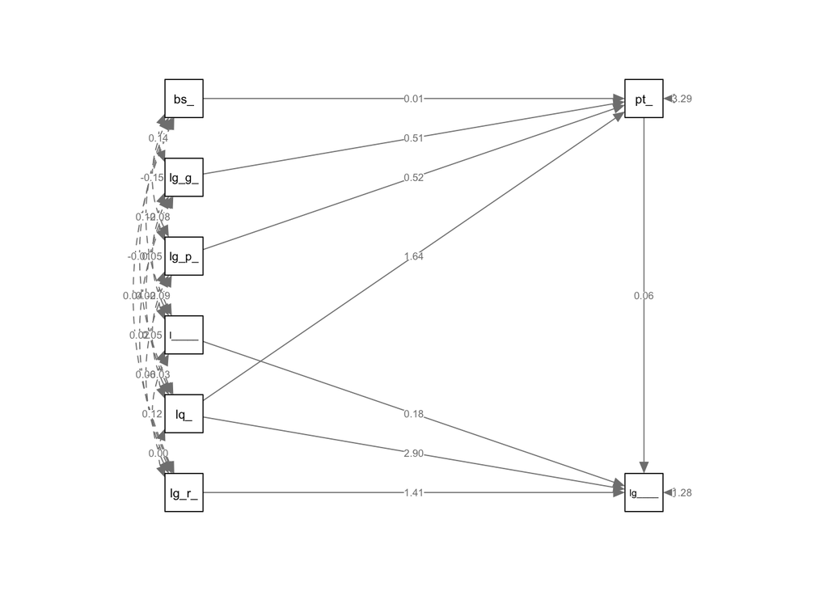

```r
# Gráfico del modelo SEM
semPaths(fit1, what = "paths", whatLabels = "par", style = "lisrel", rotation = 2)
```

### Modelo 2 - Educación de Alto Nivel y NIED

```r
nearshoring_clean$college_lqt_interaction <- nearshoring_clean$college_education * nearshoring_clean$lq_tertiary

model2 <- '
  log_real_mxn_new_fdi ~ log_real_wage + lq_tertiary + border_distance + college_education + college_lqt_interaction
  college_education ~ log_real_wage + patents_rate + inpc
'

fit2 <- sem(model2, data = nearshoring_clean)
varTable(fit2)
```

```
##                      name idx nobs    type exo user    mean       var nlev lnam
## 1    log_real_mxn_new_fdi  27  518 numeric   0    0   8.094     1.754    0
## 2       college_education  26  544 numeric   0    0   0.211     0.004    0
## 3           log_real_wage  29  544 numeric   1    0   5.746     0.018    0
## 4             lq_tertiary  20  544 numeric   1    0   0.984     0.018    0
## 5         border_distance  24  544 numeric   1    0 704.917 75066.611    0
## 6 college_lqt_interaction  33  544 numeric   1    0   0.212     0.007    0
## 7            patents_rate  21  544 numeric   1    0   1.453     3.752    0
## 8                    inpc  23  544 numeric   1    0  89.084   328.326    0
```

```r
summary(fit2, fit.measures = TRUE, standardized = TRUE, rsquare = TRUE)
```

```
## lavaan 0.6-19 ended normally after 2 iterations
##
##   Estimator                                         ML
##   Optimization method                           NLMINB
##   Number of model parameters                        10
##
##                                                   Used       Total
##   Number of observations                           518         544
##
## Model Test User Model:
##
##   Test statistic                              1645.514
##   Degrees of freedom                                 5
##   P-value (Chi-square)                           0.000
##
## Model Test Baseline Model:
##
##   Test statistic                              5087.793
##   Degrees of freedom                                13
##   P-value                                        0.000
##
## User Model versus Baseline Model:
##
##   Comparative Fit Index (CFI)                    0.677
##   Tucker-Lewis Index (TLI)                       0.160
##
## Loglikelihood and Information Criteria:
##
##   Loglikelihood user model (H0)                156.811
##   Loglikelihood unrestricted model (H1)        979.568
##
##   Akaike (AIC)                                -293.622
##   Bayesian (BIC)                              -251.122
##   Sample-size adjusted Bayesian (SABIC)       -282.864
##
## Root Mean Square Error of Approximation:
##
##   RMSEA                                          0.796
##   90 Percent confidence interval - lower         0.764
##   90 Percent confidence interval - upper         0.828
```

[output cut: 31 more lines]

```
##     0.841
##
##     0.261
##     0.086
##     0.597
##
## Variances:
##                    Estimate   Std.Err  z-value  P(>|z|)   Std.lv   Std.all
##    .lg_rl_mxn_nw_f     1.215    0.075   16.093    0.000     1.215    0.328
##    .college_eductn     0.002    0.000   16.093    0.000     0.002    0.424
##
## R-Square:
##                    Estimate
##     lg_rl_mxn_nw_f     0.672
##     college_eductn     0.576
```

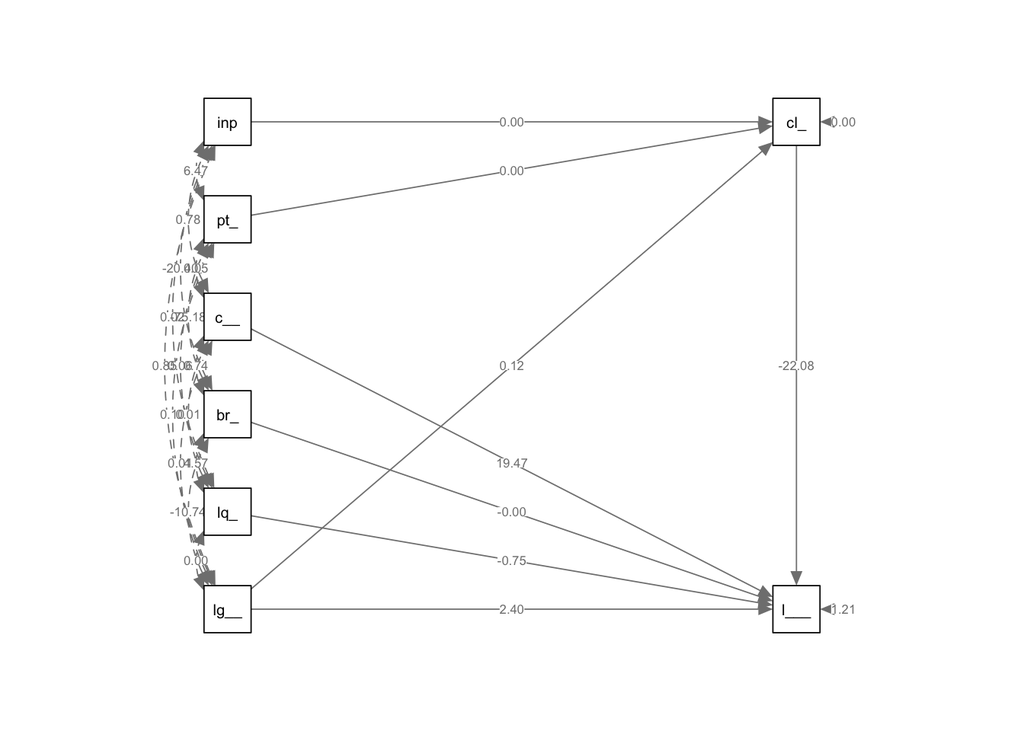

```r
# Gráfico del modelo SEM
semPaths(fit2, what = "paths", whatLabels = "par", style = "lisrel", rotation = 2)
```

### Modelo 3 - Salario Real y NIED

```r
model3 <- '
  log_real_mxn_new_fdi ~ log_real_wage + lq_tertiary + business_activity + border_distance
  log_real_wage ~ college_education + log_real_mxn_exports_miles_dlls + region_num
'

fit3 <- sem(model3, data = nearshoring_clean)
varTable(fit3)
```

```
##                              name idx nobs    type exo user    mean       var
## 1            log_real_mxn_new_fdi  27  518 numeric   0    0   8.094     1.754
## 2                   log_real_wage  29  544 numeric   0    0   5.746     0.018
## 3                     lq_tertiary  20  544 numeric   1    0   0.984     0.018
## 4               business_activity  14  544 numeric   1    0  -1.757     0.900
## 5                 border_distance  24  544 numeric   1    0 704.917 75066.611
## 6               college_education  26  544 numeric   1    0   0.211     0.004
## 7 log_real_mxn_exports_miles_dlls  32  512 numeric   1    0  17.955     3.332
## 8                      region_num   4  544 numeric   1    0   3.188     2.094
##   nlev lnam
## 1    0
## 2    0
## 3    0
## 4    0
## 5    0
## 6    0
## 7    0
## 8    0
```

```r
summary(fit3, fit.measures = TRUE, standardized = TRUE, rsquare = TRUE)
```

```
## lavaan 0.6-19 ended normally after 1 iteration
##
##   Estimator                                         ML
##   Optimization method                           NLMINB
##   Number of model parameters                         9
##
##                                                   Used       Total
##   Number of observations                           488         544
##
## Model Test User Model:
##
##   Test statistic                                57.713
##   Degrees of freedom                                 6
##   P-value (Chi-square)                           0.000
##
## Model Test Baseline Model:
##
##   Test statistic                              2253.053
##   Degrees of freedom                                13
##   P-value                                        0.000
##
## User Model versus Baseline Model:
##
##   Comparative Fit Index (CFI)                    0.977
##   Tucker-Lewis Index (TLI)                       0.950
##
## Loglikelihood and Information Criteria:
##
##   Loglikelihood user model (H0)               -307.183
##   Loglikelihood unrestricted model (H1)       -278.327
##
##   Akaike (AIC)                                 632.366
##   Bayesian (BIC)                               670.079
##   Sample-size adjusted Bayesian (SABIC)        641.513
##
## Root Mean Square Error of Approximation:
##
##   RMSEA                                          0.133
##   90 Percent confidence interval - lower         0.103
##   90 Percent confidence interval - upper         0.165
```

[output cut: 29 more lines]

```
##    -0.384
##
##     0.449
##     0.417
##    -0.109
##
## Variances:
##                    Estimate   Std.Err  z-value  P(>|z|)   Std.lv   Std.all
##    .lg_rl_mxn_nw_f     1.239    0.079   15.620    0.000     1.239    0.721
##    .log_real_wage      0.010    0.001   15.620    0.000     0.010    0.544
##
## R-Square:
##                    Estimate
##     lg_rl_mxn_nw_f     0.279
##     log_real_wage      0.456
```

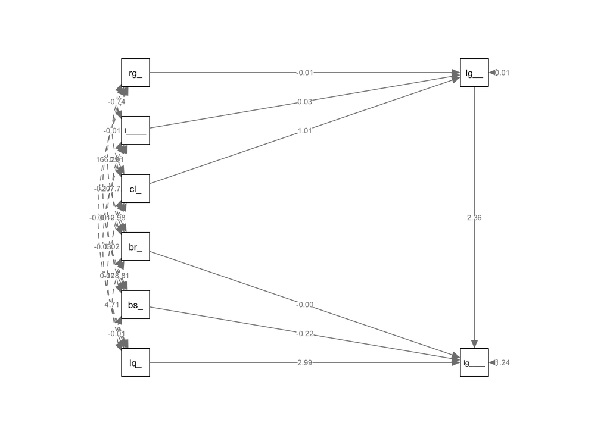

```r
# Gráfico del modelo SEM
semPaths(fit3, what = "paths", whatLabels = "par", style = "lisrel", rotation = 2)
```